# NYC Airbnb

Jeff Goldsmith

10/9/2017

## Data import

I’ll load the tidyverse and the dataset. I’m also doing a bit of editing and renaming to make my life easier.

```r
library(tidyverse)
airbnb_data = read_csv("./data/nyc_airbnb.zip") %>%
  mutate(rating = review_scores_location / 2) %>%
  rename(boro = neighbourhood_group)
```

## Understanding variables

Next I’ll do a bit of inspection to make sure I understand the data structure.

```r
# View(airbnb_data)
str(airbnb_data)
```

```
## Classes 'tbl_df', 'tbl' and 'data.frame':    40753 obs. of  18 variables:
##  $ id                            : int  7949480 16042478 1886820 6627449 5557381 9147025 11675715 715270 17876530 182177 ...
##  $ review_scores_location        : int  10 NA NA 10 10 10 10 9 10 9 ...
##  $ name                          : chr  "City Island Sanctuary relaxing BR & Bath w Parking" "WATERFRONT STUDIO APARTMENT" "Quaint City Island Community." "Large 1 BDRM in Great location" ...
##  $ host_id                       : int  119445 9117975 9815788 13886510 28811542 403032 56714504 3684360 11305944 873273 ...
##  $ host_name                     : chr  "Linda & Didier" "Collins" "Steve" "Arlene" ...
##  $ boro                          : chr  "Bronx" "Bronx" "Bronx" "Bronx" ...
##  $ neighbourhood                 : chr  "City Island" "City Island" "City Island" "City Island" ...
##  $ latitude                      : num  40.9 40.9 40.8 40.8 40.9 ...
##  $ longitude                     : num  -73.8 -73.8 -73.8 -73.8 -73.8 ...
##  $ room_type                     : chr  "Private room" "Private room" "Entire home/apt" "Entire home/apt" ...
##  $ price                         : int  99 200 300 125 69 125 85 39 95 125 ...
##  $ minimum_nights                : int  1 7 7 3 3 2 1 2 3 2 ...
##  $ number_of_reviews             : int  25 0 0 12 86 41 74 114 5 206 ...
##  $ last_review                   : Date, format: "2017-04-23" NA ...
##  $ reviews_per_month             : num  1.59 NA NA 0.54 3.63 2.48 5.43 2.06 5 2.98 ...
##  $ calculated_host_listings_count: int  1 1 1 1 1 1 1 4 3 4 ...
##  $ availability_365              : int  170 180 365 335 352 129 306 306 144 106 ...
##  $ rating                        : num  5 NA NA 5 5 5 5 4.5 5 4.5 ...
```

```r
airbnb_data %>%
  count(boro)
```

```
## # A tibble: 5 x 2
##            boro     n
##           <chr> <int>
## 1         Bronx   649
## 2      Brooklyn 16810
## 3     Manhattan 19212
## 4        Queens  3821
## 5 Staten Island   261
```

```r
airbnb_data %>%
  count(room_type)
```

```
## # A tibble: 3 x 2
##         room_type     n
##             <chr> <int>
## 1 Entire home/apt 19937
## 2    Private room 19626
## 3     Shared room  1190
```

## Brainstorming questions

### Does rating vary by neighborhood, room type, or both?

First I’ll create a table to look at rating by boro.

```r
airbnb_data %>%
  group_by(boro) %>%
  filter(!is.na(rating)) %>%
  summarize(median_rating = median(rating),
            mean_rating = mean(rating),
            sd_rating = sd(rating))
```

```
## # A tibble: 5 x 4
##            boro median_rating mean_rating sd_rating
##           <chr>         <dbl>       <dbl>     <dbl>
## 1         Bronx           4.5    4.444444 0.4832429
## 2      Brooklyn           5.0    4.645007 0.4519313
## 3     Manhattan           5.0    4.785744 0.3645893
## 4        Queens           4.5    4.651240 0.4303368
## 5 Staten Island           4.5    4.618280 0.4119686
```

Next I’ll try some visual displays.

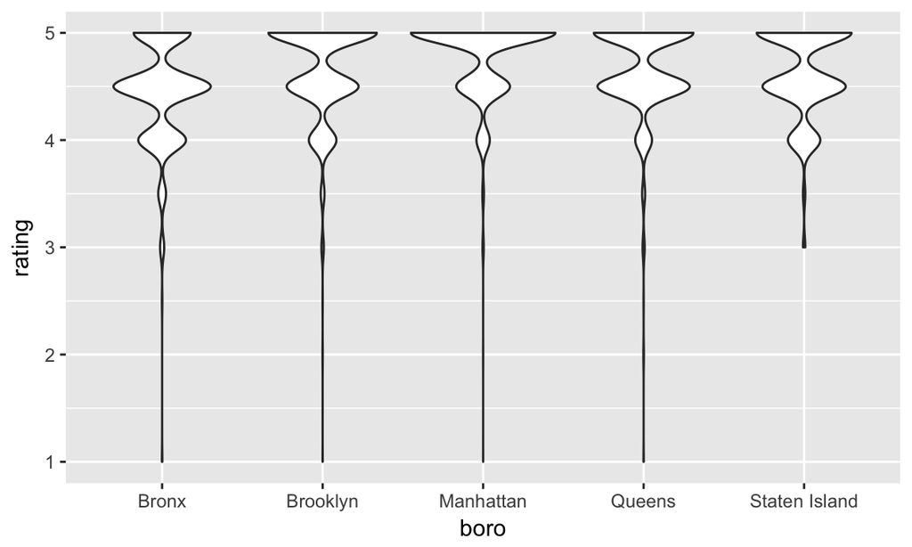

```r
airbnb_data %>%
  ggplot(aes(x = boro, y = rating)) +
  geom_violin(bw = .1)
```

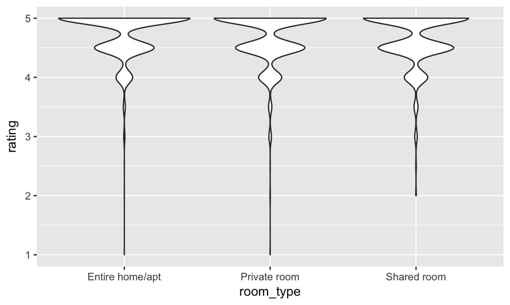

```r
airbnb_data %>%
  ggplot(aes(x = room_type, y = rating)) +
  geom_violin(bw = .1)
```

Finally, I’m interested in the `room_type` variable. Rating didn’t seem to vary much across this variable, but I’d still like to examine this and boro at the same time.

The chunk below creates a table, and then uses `knitr::kable()` to format the output.

```r
airbnb_data %>%
  group_by(boro, room_type) %>%
  filter(!is.na(rating)) %>%
  summarize(mean_rating = mean(rating)) %>%
  spread(key = boro, value = mean_rating) %>%
  knitr::kable()
```

| room_type | Bronx | Brooklyn | Manhattan | Queens | Staten Island |
| --- | --- | --- | --- | --- | --- |
| Entire home/apt | 4.445652 | 4.676650 | 4.815377 | 4.689802 | 4.637500 |
| Private room | 4.451613 | 4.620142 | 4.741297 | 4.636719 | 4.604762 |
| Shared room | 4.325000 | 4.516791 | 4.782297 | 4.532143 | 4.500000 |

### Do hosts with more listings have higher or lower ratings?

First I’ll look at the number of properties by each host. This code gave me some trouble in class – the first try and the better approach are both shown below.

```r
airbnb_data %>%
  count(calculated_host_listings_count)
```

```
## # A tibble: 21 x 2
##    calculated_host_listings_count     n
##                             <int> <int>
##  1                              1 30356
##  2                              2  5486
##  3                              3  2040
##  4                              4  1008
##  5                              5   545
##  6                              6   360
##  7                              7   245
##  8                              8   208
##  9                              9    72
## 10                             10    90
## # ... with 11 more rows
```

```r
airbnb_data %>%
  count(host_id) %>%
  count(n)
```

```
## # A tibble: 21 x 2
##        n    nn
##    <int> <int>
##  1     1 30356
##  2     2  2743
##  3     3   680
##  4     4   252
##  5     5   109
##  6     6    60
##  7     7    35
##  8     8    26
##  9     9     8
## 10    10     9
## # ... with 11 more rows
```

We’ll use `calculated_host_listings_count` moving forward for this question – that gives the total number of rentals that are hosted by the host in the row.

I’ll try to answer this using a scatterplot

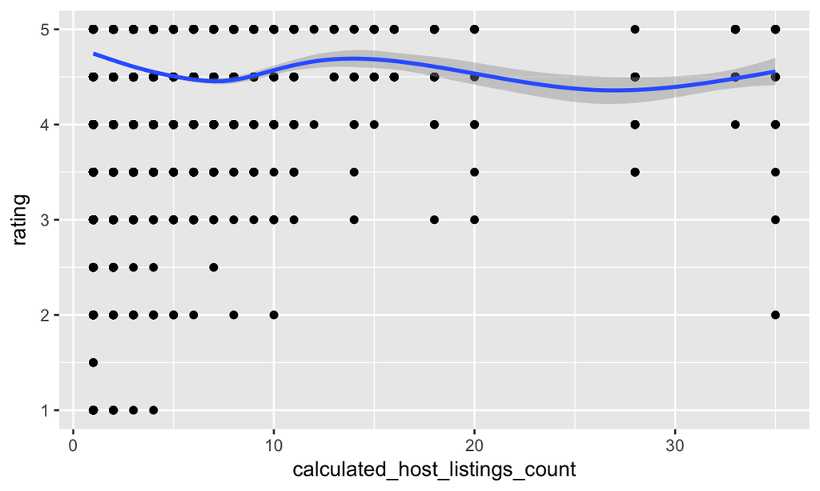

```r
airbnb_data %>%
  ggplot(aes(x = calculated_host_listings_count, y = rating)) +
  geom_point() +
  geom_smooth()
```

I’ll also try to answer this using a numeric summary for a binary `lots_of_houses` variable.

```r
airbnb_data %>%
  filter(!is.na(rating)) %>%
  mutate(lots_of_houses = (calculated_host_listings_count > 1)) %>%
  group_by(lots_of_houses) %>%
  summarize(median_rating = median(rating),
            mean_rating = mean(rating),
            sd_rating = sd(rating))
```

```
## # A tibble: 2 x 4
##   lots_of_houses median_rating mean_rating sd_rating
##            <lgl>         <dbl>       <dbl>     <dbl>
## 1          FALSE           5.0    4.745917 0.4016954
## 2           TRUE           4.5    4.617015 0.4433053
```

If anything, hosts with lots of apartments have slightly lower ratings.

### Where are rentals located?

I’m going to use [latitude](https://en.wikipedia.org/wiki/Latitude) and [longitude](https://en.wikipedia.org/wiki/Longitude) to plot the location of rentals. I always get lat and mixed up, and it seems like the person who put these data together did as well …

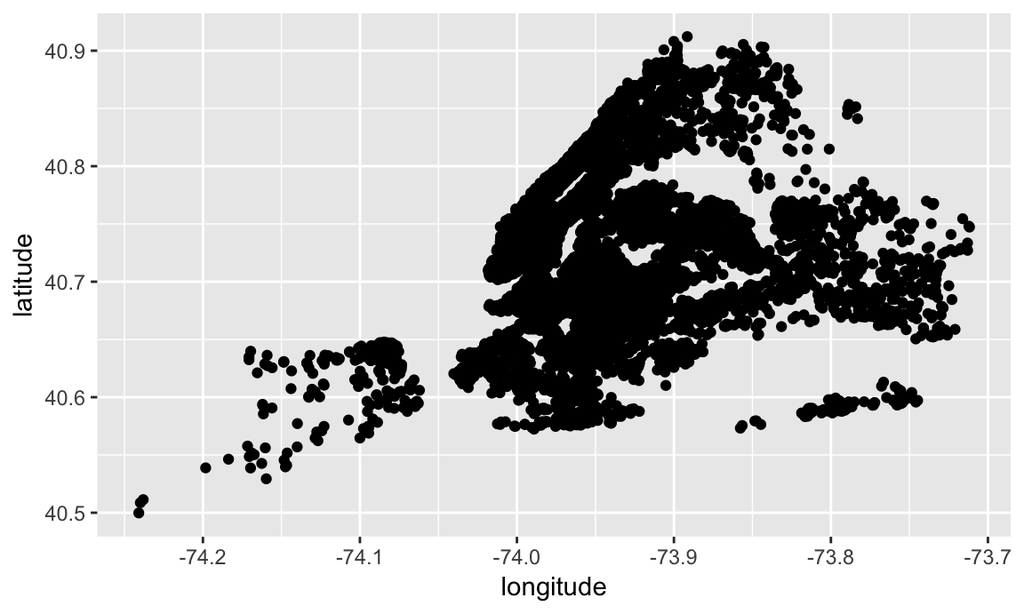

```r
airbnb_data %>%
  ggplot(aes(x = longitude, y = latitude)) +
  geom_point()
```

Next I’ll try to clean this up a bit and use other aesthetic mappings. For simplicity, I’ll also focus on Manhattan.

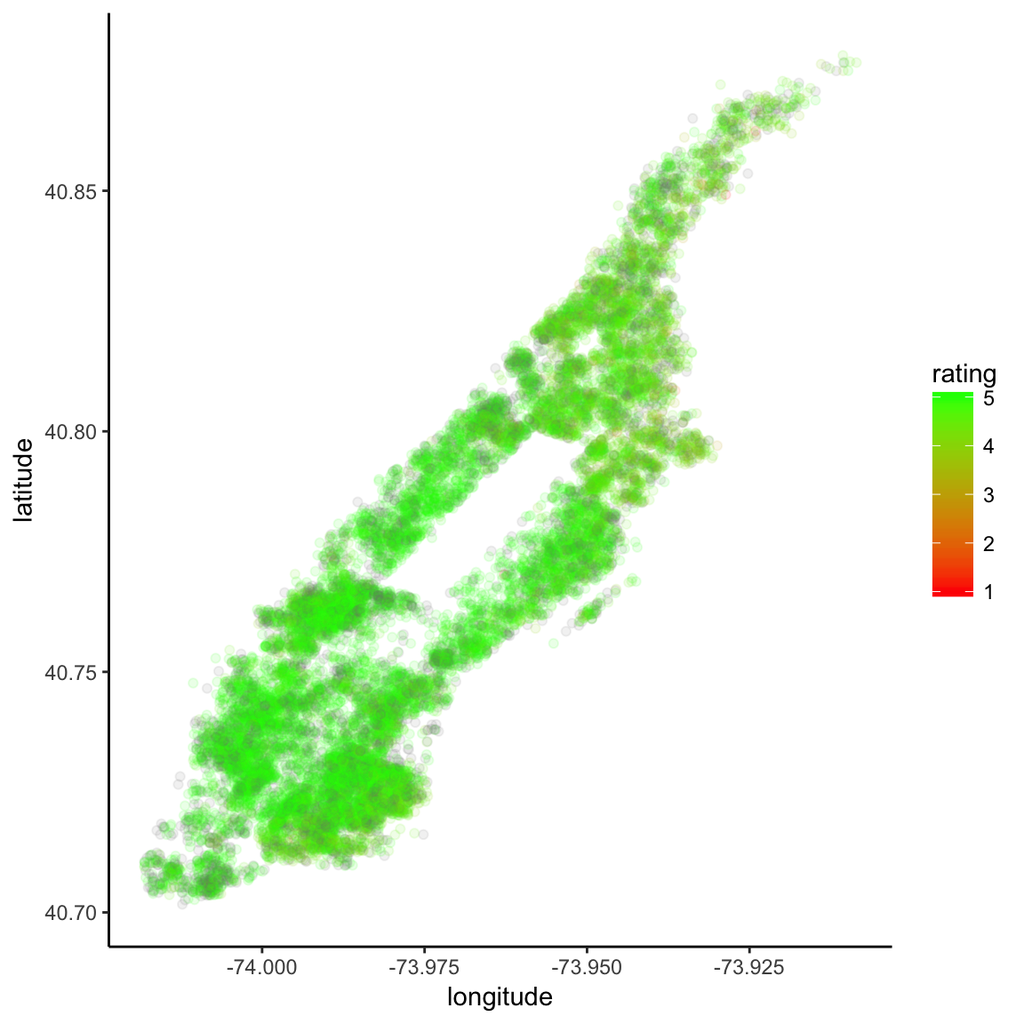

```r
airbnb_data %>%
  filter(boro == "Manhattan") %>%
  ggplot(aes(x = longitude, y = latitude, color = rating)) +
  geom_point(alpha = .1) +
  scale_colour_gradient(low = "red", high = "green",
  space = "Lab", na.value = "grey50", guide = "colourbar") +
  coord_cartesian() +
  theme_classic()
```

We can learn quite a bit from this – there are fewer rentals in some neighborhoods of Manhattan than others, and there seems to be a slight decrease in rating for rentals farther north than downtown.

### Other questions

There are several questions we didn’t get to:

- How is price related to other variables?
- How are descriptions related to number of reviews?
- Which rentals make the most money?
- What’s different about low-availability rooms?

Of these, the question dealing with descriptions is one we’re not in a position to handle yet – that involves parsing character strings, which we’ll get to shortly. The others we could at least explore using the tools we have at our disposal now.